# Visium NSCLC: benchmarking cell type deconvolution methods

```r
tempMarkerPlot <- function(marker){
  p <- VizSpatial(
    qu_vis, feature = marker, assay2use = "log1p", ptSize = 0.6
  )
  p <- p + xlim(1400, 12500) + ylim(-14000, -3500) +
    theme(
      legend.text = element_text(size = 6),
      legend.title = element_text(size = 6)
    ) +
    theme_void()
  ggsave(
    paste0("figs/specialCases/", VisTissueName, "_", marker, "_spatial.png"),
    p + theme(legend.position = "none"),
    width = 1.5, height = 1.5
  )

  return(p)
}
tempMarkerPlot("KRT19") #also known as CYFRA21-1
```

```
Cannot find directory figs/specialCases.
ℹ Would you like to create a new directory?

1: Yes
2: No
```

```
✔ Created directory: figs/specialCases.
```

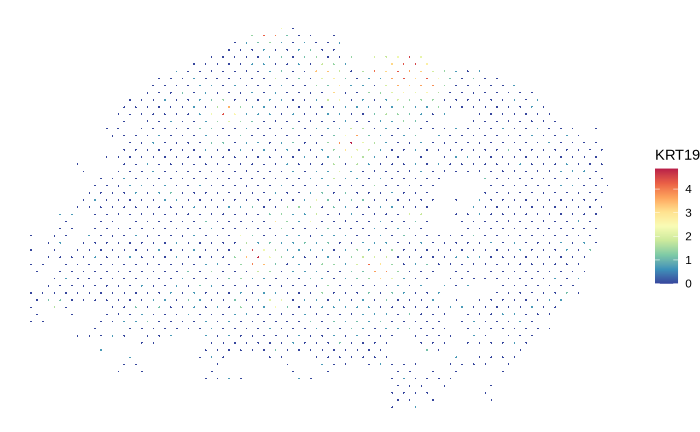

```r
1
```

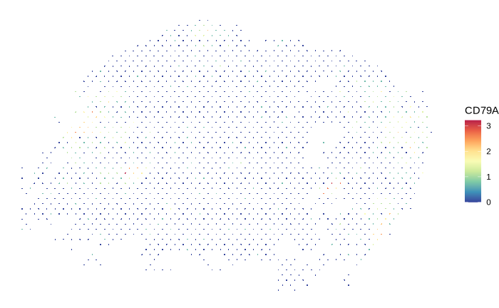

```r
tempMarkerPlot("CD79A")
```

B cell spatial distribution

```r
cType <- "B cells"
p_list <- list(
  PhiSpace =
    VizSpatial(qu_vis, ptSize = 0.6, reducedDim = cType, reducedDim2use = "PhiSpace", censor = T),
  RCTD = VizSpatial(qu_vis, ptSize = 0.6, reducedDim = cType, reducedDim2use = "RCTD"),
  cell2location = VizSpatial(qu_vis, ptSize = 0.6, reducedDim = cType, reducedDim2use = "c2l_q05"),
  TACCO = VizSpatial(qu_vis, ptSize = 0.6, reducedDim = cType, reducedDim2use = "TACCO")
)
p_list <- lapply(
  1:length(p_list),
  function(x){

    methodName <- names(p_list)[x]
    p_list[[methodName]]  +
      theme(
        legend.position = "top",
        legend.title = element_text(size = 6),
        legend.text = element_text(size = 6)
      ) +
      xlim(1400, 12500) + ylim(-14000, -3500) +
      theme_void()
  }
)
ggarrange(
  plotlist = p_list, nrow = 1, legend = "none"
)
ggsave(
  "figs/specialCases/InconsistentAnn.png",
  width = 6, height = 1.5
)
```

[output not shown]

Signatures of cancer regions (according to marker).

```r
tempSavePlots(
  qu_vis, "PhiSpace", tissueName = VisTissueName, coordNames = c("x", "y"),
  freeColScale = T, censQuant = 0.5, psize = 1
)
```

Venn diagram for number of meaningful markers for B cell abundance prediction.

```r
p <- tempVenn(
      outList_Phi[[cType]],  AzimuthMarkers = AzimuthMk2Use, title = "PhiSpace", fsize = 5
    )$plot
ggsave(
    paste0("figs/specialCases/", VisTissueName, "_", gsub(" ", "_", cType), "_Venn", 1, ".png"),
    p,
    width = 1.5, height = 1.5
)
p <- tempVenn(
      outList_RCTD[[cType]],
      AzimuthMarkers = AzimuthMk2Use,
      title = "RCTD", fsize = 5
    )$plot
ggsave(
    paste0("figs/specialCases/", VisTissueName, "_", gsub(" ", "_", cType), "_Venn", 2, ".png"),
    p,
    width = 1.5, height = 1.5
)
p <- tempVenn(
      outList_c2l[[cType]],
      AzimuthMarkers = AzimuthMk2Use,
      title = "cell2location", fsize = 5
    )$plot
ggsave(
    paste0("figs/specialCases/", VisTissueName, "_", gsub(" ", "_", cType), "_Venn", 3, ".png"),
    p,
    width = 1.5, height = 1.5
)
p <- tempVenn(
      outList_TACCO[[cType]],
      AzimuthMarkers = AzimuthMk2Use,
      title = "TACCO", fsize = 5
    )$plot
ggsave(
    paste0("figs/specialCases/", VisTissueName, "_", gsub(" ", "_", cType), "_Venn", 4, ".png"),
    p,
    width = 1.5, height = 1.5
)
```

```r
if(T){

  cTypes <- names(outList_Phi)
} else {

  cTypes <- intersect(
    names(outList_Phi), names(AzimuthMarkers)
  )
}
mks <- matrix(NA, length(cTypes), 4) %>%
  `rownames<-`(cTypes) %>%
  `colnames<-`(c(
    "PhiSpace",
    "cell2location",
    "RCTD",
    "TACCO"
  ))
for(i in 1:length(cTypes)){

  cType <- cTypes[i]
  mks[cType,] <- c(
    PhiSpace = tempVenn(
      outList_Phi[[cType]],
      AzimuthMarkers = AzimuthMk2Use,
      plotVenn = F
    )$intersection,
    cell2location = tempVenn(
      outList_c2l[[cType]],
      AzimuthMarkers = AzimuthMk2Use,
      plotVenn = F
    )$intersection,
    RCTD = tempVenn(
      outList_RCTD[[cType]],
      AzimuthMarkers = AzimuthMk2Use,
      plotVenn = F
    )$intersection,
    TACCO = tempVenn(
      outList_TACCO[[cType]],
      AzimuthMarkers = AzimuthMk2Use,
      plotVenn = F
    )$intersection
  )
}

p <- ggplot(
  mks %>%
    as.data.frame() %>%
    pivot_longer(
      everything(),
      names_to = "method",
      values_to = "num_mks"
    ) %>%
    mutate(
      method = factor(method, levels = c("TACCO", "cell2location", "RCTD", "PhiSpace"))
    ),
  aes(x = num_mks, y = method)
) +
  geom_boxplot(
    aes(colour = method), outliers = F
  ) +
  geom_jitter(
    aes(colour = method), size = 0.5
  ) +
  theme_pubr(base_size = 6) +
  xlab(paste0("Number of meaningful markers (", VisTissueName, ")")) + ylab("") +
  theme(
    legend.position = "none"
  )
p
ggsave(
  paste0("figs/specialCases", VisTissueName, "_markerBox.png"),
  p,
  width = 3, height = 1.5
)
mks %>% colMeans()
```

[output not shown]

The distribtuions appear to be zero-inflated. Fit a ZINB.

```r
fitRes <- apply(mks, 2, fitZINB) %>%
  unlist()
fitRes
```

[output not shown]

# All tissues

Run `DEG_res_all_tissues.R` first to get spatial DEG results for all tissues.

```r
deg_summ <- readRDS(paste0(dat_dir, "output/Case3/DEG_summ", Mk2Use, ".rds"))
out <- deg_summ[[1]]
outList <- deg_summ[[2]]

# mean marker socres
MMS <- out %>%
  as.data.frame() %>%
  mutate(tissueNames = tissueNames) %>%
  pivot_longer(
    ! c(tissueNames),
    names_to = "methods",
    values_to = "mean marker score"
  ) %>%
  mutate(
    methods = factor(methods, levels = c("TACCO", "cell2location", "RCTD", "PhiSpace"))
  )

# ZINB parameters
ZINBparam <- do.call(
  "rbind", outList
) %>%
  pivot_longer(
    mu:ZIprob,
    names_to = "parameter_type",
    values_to = "parameter"
  )

p_MMS <-  ggplot(
    MMS,
    aes(x = `mean marker score`, y = methods, colour = methods)
  ) +
    geom_boxplot(
      outliers = F
    ) +
    geom_jitter(
      size = 0.5
    ) +
    theme_pubr(base_size = 6) +
    xlab("Mean number of meaningful markers (all tissues)") + ylab("") +
    theme(
      legend.position = "none"
    )
p_MMS
ggsave(
  paste0("figs/MMS_box_", Mk2Use, ".png"),
  p_MMS,
  width = 3, height = 1.5
)
```

[output not shown]

# Cell type co-presence.

```r
PhiResPath <- paste0(
  dat_dir,
  "output/Case3/PhiSpace/combo_PhiRes.qs"
)
PhiRes <- qread(PhiResPath)[1:18]

# Victorise cell type correlation matrices
VisTissueNames <- tissueNames_Visium[1:18]
corMat_list <- vector("list", length(VisTissueNames)) %>% `names<-`(VisTissueNames)
for(ii in 1:length(VisTissueNames)){

  VisTissueName <- VisTissueNames[ii]
  PhiScores_norm <- normPhiScores(PhiRes$PhiSpaceScore[[VisTissueName]])
  corMat <- cor(PhiScores_norm)
  corMat_list[[ii]] <- corMat
}
cTypeCombo <- outer(
  rownames(corMat_list[[1]]), colnames(corMat_list[[1]]),
  function(x, y) paste0(x, "<->", y)
)
corMatVec <- sapply(
  corMat_list,
  function(x) as.vector(x[lower.tri(x)])
) %>%
  `colnames<-`(VisTissueNames) %>%
  `rownames<-`(
    cTypeCombo[lower.tri(cTypeCombo)]
  ) %>%
  t()

## PCA analysis of all co-presence matrices
intVars <- colVars(corMatVec)
selectedInt <- names(intVars)
set.seed(92394)
pca_res <- getPC(corMatVec[,selectedInt], ncomp = 2, center = T, scale = F)
p <- tempPCAplot(pca_res) + expand_limits(x = c(-5.5, 7.5))
p
ggsave(
  "figs/copresence/Visium_PhiNet_MDS.png",
  p + theme(legend.position = "none"), width = 3, height = 3
)
```

```r
png(
  "figs/copresence/Visium_PhiNet_MDS_legend.png",
  width = 2, height = 0.2, units = "in", res = 300
)
op <- par(mar = rep(0, 4))
grid::grid.draw(get_legend(p))
```

[figure not shown]

```r
par(op)
dev.off()
```

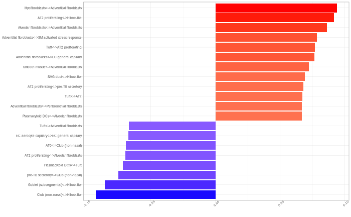

```r
# Specialised PCA plots (PCA of signs, PCA of absolute values)
if(F){
  pcaAbs_res <- getPC(abs(corMatVec[,selectedInt]), ncomp = 2, center = T, scale = F)
  pcaSign_res <- getPC(sign(corMatVec[,selectedInt]), ncomp = 2, center = T, scale = F)
  tempPCAplot(pca_res)
  tempPCAplot(pcaAbs_res)
  tempPCAplot(pcaSign_res)
}
## Loading plots
loadBarplot(pca_res$loadings, nfeat = 20, fsize = 6) + theme(axis.text.x = element_text(angle = 45))
ggsave("figs/copresence/Visium_cTypeInt_comp1_loading.png", width = 3, height = 3)
```

Prognosis markers CELSR2 is a marker for better prognosis in LUSC; KRT17, KRT6A, S100A2, TRIM29, REPS1, and GPC1 are markers for worse prognosis in LUAD

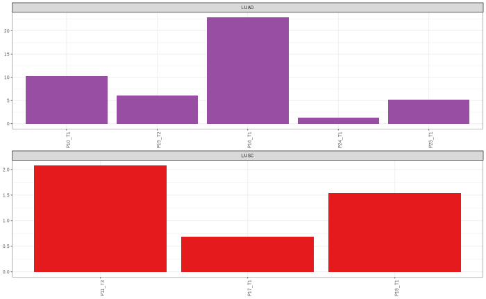

```r
# Common gene of all Visium slides
commonGeneNames <- Reduce(
  intersect,
  lapply(
    query_list[1:18], function(x) rownames(x)
  )
)
mk_list <- list(
  LUSC_good = c("CELSR2"),
  LUAD_bad = c("KRT17", "KRT6A", "S100A2", "TRIM29", "REPS1", "GPC1"),
  LUAD_good = c("PERP", "ELFN2", "ARHGAP12", "QSOX1")
)
mk_list <- lapply(mk_list, function(x) intersect(x, commonGeneNames))
# Function for calculate mean expression level of marker genes in all tissues
assay2use <- "counts"
meanGeneLvls <- sapply(
  query_list[1:18],
  function(x){
    mean(rowSums(assay(x, assay2use)))
  }
)
mkLvls_LUSC <- data.frame(favourable = meanEsts(mk_list[["LUSC_good"]]))
mkLvls_LUAD_good <- data.frame(favourable = meanEsts(mk_list[["LUAD_good"]]))
mkLvls_LUAD_bad <- data.frame(favourable = meanEsts(mk_list[["LUAD_bad"]]))
mkLvls_LUAD <- mkLvls_LUAD_good/mkLvls_LUAD_bad
p <- data.frame(
  favourable = c(
    mkLvls_LUSC[Visium_cancerTypes == "LUSC",],
    mkLvls_LUAD[Visium_cancerTypes == "LUAD",]
  ),
  sample = c(
    tissueNames[Visium_cancerTypes == "LUSC"],
    tissueNames[Visium_cancerTypes == "LUAD"]
  ),
  cancerType = c(
    Visium_cancerTypes[Visium_cancerTypes == "LUSC"],
    Visium_cancerTypes[Visium_cancerTypes == "LUAD"]
  )
) %>%
  ggplot() +
  geom_bar(
    aes(
      sample, favourable, fill = cancerType
    ),
    stat = "identity"
  ) +
  # scale_y_continuous(transform = "log2") +
  scale_fill_manual(values = VisiumCancerCols) +
  theme_bw(base_size = 6) +
  theme(
    axis.text.x = element_text(angle = 90),
    axis.title.x = element_blank()
  ) +
  facet_wrap(~cancerType, scales = "free", ncol = 1) +
  theme(
    legend.position = "none",
    axis.title.y = element_blank()
  )
p
ggsave(
  "figs/copresence/sample_prognosis_score.png",
  p, width = 1, height = 3
)
```

Interactions involving immune cell types.

```r
immuneDF <- data.frame(
  celltype = rownames(corMat_list[[1]]),
  immuneOrNot = c(
    "immune", "immune", "other",
    "immune", "other", "other",
    "other", "immune", "other",
    "other", "immune", "other",
    "other", "immune", "other",
    "other", "other", "other",
    "immune", "immune", "immune",
    "other", "other", "other",
    "immune", "other", "other",
    "other", "other", "other",
    "other", "other", "other",
    "other", "other", "other",
    "immune", "immune", "other",
    "immune", "immune", "immune",
    "other", "other", "other",
    "other", "other", "other",
    "other", "other", "other",
    "immune", "other", "other",
    "other", "immune", "immune",
    "other", "other", "other",
    "immune"
  )
)
immuneCellTypes <- immuneDF$celltype[immuneDF$immuneOrNot == "immune"]
intDF <- do.call("rbind", stringr::str_split(colnames(corMatVec), "<->"))
intIdx <- apply(
  intDF, 1,
  function(x) (x[1] %in% immuneCellTypes) | (x[2] %in% immuneCellTypes)
)
set.seed(92399)
corMatVec_immune <- corMatVec[,intIdx]
pcaImmune_res <- getPC(corMatVec_immune, ncomp = 2, center = T, scale = F)
p <- tempPCAplot(pcaImmune_res) + expand_limits(x = c(-4, 4))
ggsave(
  "figs/copresence/Visium_PhiNetImmune_MDS.png",
  p + theme(legend.position = "none"), width = 3, height = 2.5
)
## Loading plots
p_load <- loadBarplot(pcaImmune_res$loadings, "comp1", nfeat = 20, fsize = 6)
ggsave("figs/copresence/Visium_cTypeIntImmune_comp1_loading.png", p_load, width = 3.5, height = 2.5)
```

See `computTime.R` for evaluating computational time needed for PhiSpace and RCTD.